# Midterm Progress For Master Thesis

# "Machine Learning Approach to Polkadots Validator Election Algorithm"

### 1. Introduction

- Polkadot election of active set of validators occurs every 24 hours.
- The active set of validators is the set of validators that are eligible to produce blocks in the next 24 hours.
  - The active set is currently chosen by the Sequential Phragmén algorithm.
  - The Phragmén algorithm is an iterative method for electing a committee with proportional justified representation.
- The current configuration allows for a "staking miner" (role in experimental phase) to propose solutions to the system.
  - The staking miner is incentivised to propose solutions that are as close to the optimal solution as possible.
  - Each solution has a "security score" which is determined by 3 factors:
    1. maximise: the minimally staked validator of the active set
    2. maximise: the sum of stakes of the active set
    3. minimise: the variance of the stakes of the active set
  - The criteria get judged in order and as soon as one of the criteria is not met, the solution is rejected.

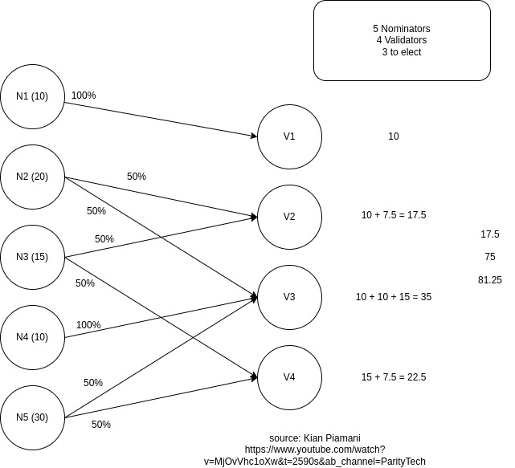

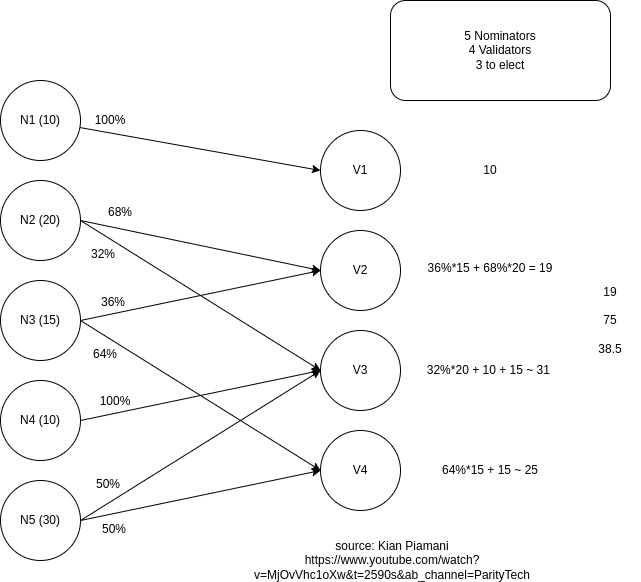

#### Breakdown into three parts:

1. Pipeline
2. Model1: Classification model: Active Set prediciton
3. Model2: Regression model: Prediction of Stake (vote) distribution

# Pipeline

Data Acquisition via storage queries (takes about 8 hours to gather data for 1 year)

- Snapshot of Nominators, their stake and their vote preferences (up to 16 validators) (leads to graph of max 22'500 nominators with max 16 votes == 360'000 edges per day)
- SolutionStored: The solution posted by staking miner by running sequential phragmén algorithm
- Local Sequential Phragmén: Running the sequential phragmén algorithm locally for a longer time to acquire a better solution than the one posted by the staking miner
- automatic snapshot acquisition via subscription of storage queries

Data Preprocessing

- Feature engineering, Feature selection, Feature scaling
- Index mapping (validator+nominator address to index)
- Restructuring of data to avoid curse of dimensionality (one-hot encoding of votes)

Model Selection, Training & Prediction

- user may select various models
- model hyperparameters are previously tuned via optuna framework

Adjustment

- Predictions do not add up to 100%
- Example:
  - Nominator X votes for 2 validators y and z with bond 100
  - Solution derived by seq. Phragmén dictates y receives 60, z receives 40
  - Prediction by model dictates y receives 40, z receives 40
    - 20 is missing, hence solution will not be accepted, must be adjusted!
- various trivial (sub-)strategies implemented
  - "even_split"
  - "weighted_split"
  - "negative_adjustment"
  - cvxpy
    - objective function: L2 norm of the difference between the predicted values and the original predictions
    - always adds up to the corresponding target value (total bond), while also minimizing the difference between the original predictions and the optimized predictions

Scoring & comparing (by 3 metrics)

- maximise: minimally backed validator
- maximise: sum of stakes
- minimise: variance of stakes

(optional) Push solution to chain

- essentially acting as a "staking miner"

# Model 1: Active Set Prediction

```python
# In order to avoid curse of dimensionality, we need to restructure the data.
df.head()
```

|  | validator | total_bond | proportional_bond | list_of_nominators | nominator_count | elected_current_era | elected_previous_era | elected_counter | avg_stake_per_nominator | era |
| --- | --- | --- | --- | --- | --- | --- | --- | --- | --- | --- |
| 0 | 1zugcag7cJVBtVRnFxv5Qftn7xKAnR6YJ9x4x3XLgGgmNnS | 173428979826227580 | 1.434129e+16 | {'1SdEjEWdfJCisR9FpnpgAoTAEUKAivLSFj2sRMeKWxXm... | 1468 | 1 | 0 | 0 | 9.769268e+12 | 590 |
| 1 | 16HxQKtm8FogERURhxaJ7n6dnvzVjnXcHP54nBFSFr6ZCqUh | 950993578466105 | 1.041153e+14 | {'1eE4N8j5sF3W1N3bf535hZ7VMpGbwyBD4MLXsKB5pxWP... | 16 | 0 | 0 | 0 | 6.507203e+12 | 590 |
| 2 | 148Ta5cWD3wekK3C6EbdDhYrdxC5e71VTKQCjmHUjE1DCG31 | 130773957029866447 | 2.031984e+16 | {'12YdvQC6ripH1RnnykQnoDSqyKyy7qX8gAR7ixLAumGs... | 61 | 1 | 0 | 0 | 3.331121e+14 | 590 |
| 3 | 1uFscCqjzMDDGRS8bh9W8f4t94WVXgvnzTeSTrdjC8fJZA6 | 972806309572318 | 1.335135e+14 | {'1M1vsos73tp6pp3zymbrxP2bAfeszLShuURcitbHTRmZ... | 138 | 0 | 0 | 0 | 9.674891e+11 | 590 |
| 4 | 123viL2RvWMFmCQQBzii6JzDUPbL6MZQa27q2VWvBpkrRran | 912207170000000 | 1.013652e+14 | {'1s1SGPC2v5pYfcDNQKFhNiscsiu9VRZVywxaAgXJuKzE... | 2 | 0 | 0 | 0 | 5.068262e+13 | 590 |

```python
scores = cross_val_score(clf, x_scaled, y, cv=10)

print("%0.6f accuracy with a standard deviation of %0.6f" % (scores.mean(), scores.std()))
```

```
0.996291 accuracy with a standard deviation of 0.002779
```

```python
scores = cross_val_score(clf, x_scaled, y, cv=10)

print("%0.6f accuracy with a standard deviation of %0.6f" % (scores.mean(), scores.std()))
```

```
0.957716 accuracy with a standard deviation of 0.003152
```

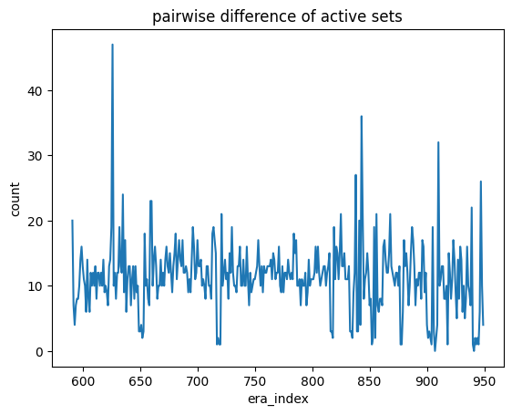

```python
plt.plot(era_index[1:], set_difference[1:])
```

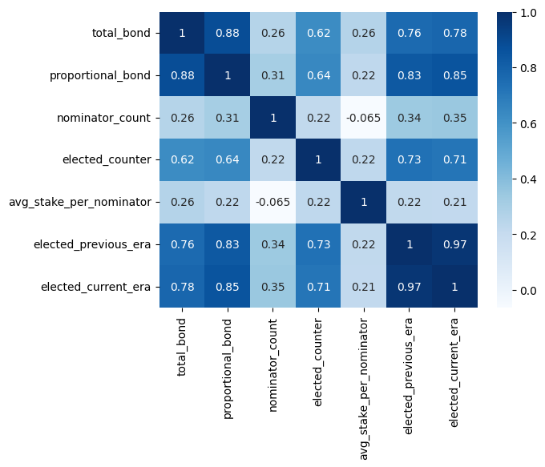

```python
sns.heatmap(heatmap_df.corr(), cmap="Blues", annot=True)
```

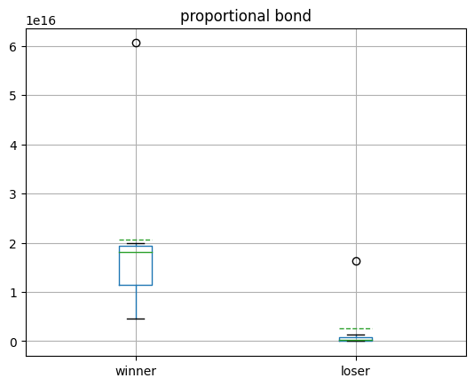

```python
concated_dfs[2].boxplot(meanline=True, showmeans=True)
plt.title("proportional bond")
```

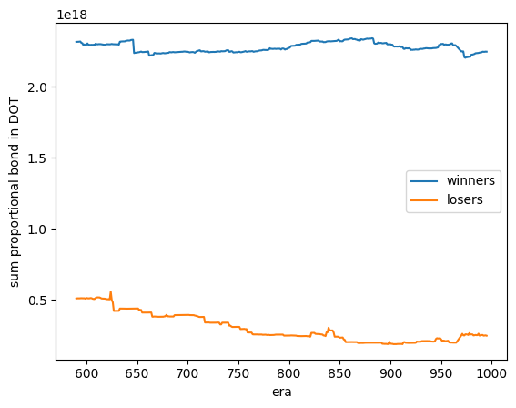

```python
proportional_bonds_winners = winner_df.groupby("era").sum('proportional_bond').reset_index()
proportional_bonds_losers = loser_df.groupby("era").sum('proportional_bond').reset_index()
plt.plot(proportional_bonds_winners['era'], proportional_bonds_winners['proportional_bond'])
plt.plot(proportional_bonds_losers['era'], proportional_bonds_losers['proportional_bond'])
plt.xlabel("era")
plt.ylabel("sum proportional bond in DOT")
plt.legend(["winners", "losers"])
plt.show()
```

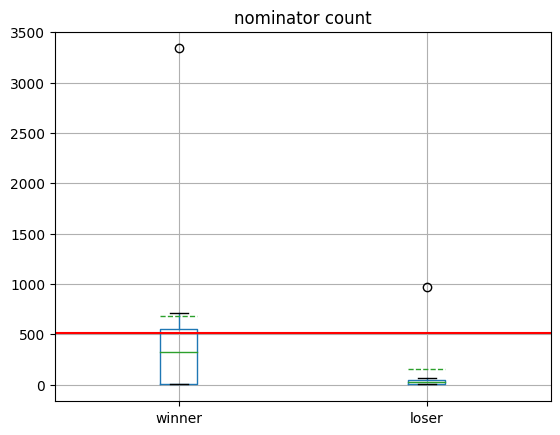

```python
# oversubscribed after 512
concated_dfs[3].boxplot(meanline=True, showmeans=True)
plt.axhline(512, c='r')
plt.title("nominator count")
```

# Model2: Regression model: Prediction of Stake (vote) distribution

```python
df.head()
```

|  | nominator | validator | era | proportional_bond | number_of_validators | total_bond | solution_bond | prev_min_stake | prev_sum_stake | prev_variance_stake | total_proportional_bond |
| --- | --- | --- | --- | --- | --- | --- | --- | --- | --- | --- | --- |
| 0 | 1zugcag7cJVBtVRnFxv5Qftn7xKAnR6YJ9x4x3XLgGgmNnS | 1zugcag7cJVBtVRnFxv5Qftn7xKAnR6YJ9x4x3XLgGgmNnS | 741 | 100000000000 | 1 | 100000000000 | 100000000000 | 17545603034426886 | 6170804944090742732 | 9.951199e+30 | 21415842498115643 |
| 1 | 148Ta5cWD3wekK3C6EbdDhYrdxC5e71VTKQCjmHUjE1DCG31 | 148Ta5cWD3wekK3C6EbdDhYrdxC5e71VTKQCjmHUjE1DCG31 | 741 | 11000000000 | 1 | 11000000000 | 11000000000 | 17545603034426886 | 6170804944090742732 | 9.951199e+30 | 24117621698208003 |
| 2 | 13JuYFD8KzXaYB5uxNvMGX7yzHyQC4n8KiSo7obeSHnncGxx | 13JuYFD8KzXaYB5uxNvMGX7yzHyQC4n8KiSo7obeSHnncGxx | 741 | 10000000000 | 1 | 10000000000 | 10000000000 | 17545603034426886 | 6170804944090742732 | 9.951199e+30 | 17438571029633832 |
| 3 | 13nFyzjzDi3jZUZMEFG2nUJ4XKChooTyjBXDQnamAJL71Wr5 | 13nFyzjzDi3jZUZMEFG2nUJ4XKChooTyjBXDQnamAJL71Wr5 | 741 | 10000000000 | 1 | 10000000000 | 10000000000 | 17545603034426886 | 6170804944090742732 | 9.951199e+30 | 9985664314557928 |
| 4 | 14N5nJ4oR4Wj36DsBcPLh1JqjvrM2Uf23No2yc2ojjCvSC24 | 14N5nJ4oR4Wj36DsBcPLh1JqjvrM2Uf23No2yc2ojjCvSC24 | 741 | 65023037973477 | 1 | 65023037973477 | 65023037973477 | 17545603034426886 | 6170804944090742732 | 9.951199e+30 | 22526691954443181 |

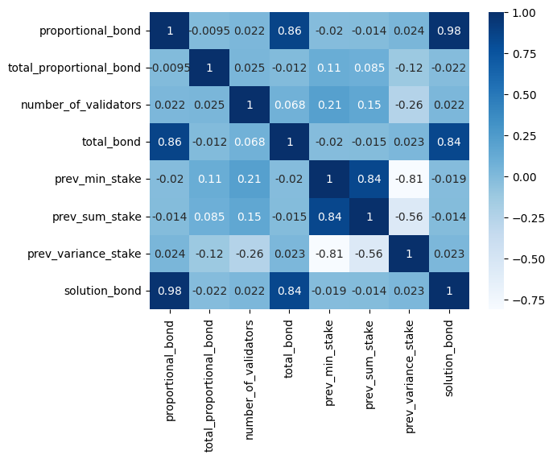

```python
sns.heatmap(heatmap_df.corr(), cmap="Blues", annot=True)
```

```python
mean_absolute_error(y_test, lr.predict(X_test))
```

```
11618542123689.914
```

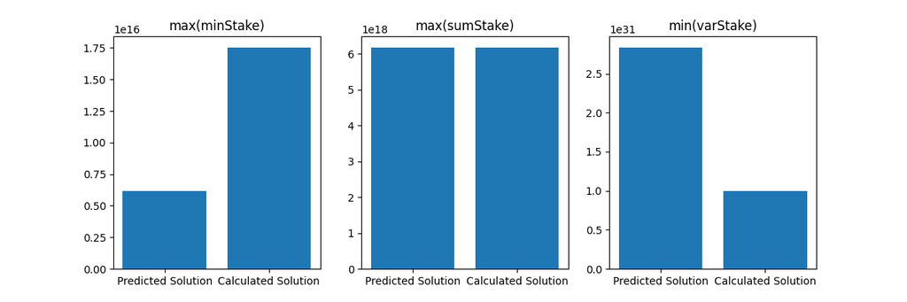

- Using Optuna (hyperparameter tuning framework to optimise models (ridge, lasso, randomforest, gradientboosting)
  - Metrics such as mae/mse useless
  - Optimising now for scoring conditions
    - Results unfortunately still not satisfying
    - Potentially skewed due to "adjustment function"
      - Potentially introduce Model 3/make model 2 an ensemble model (hierarchical reconciliation?)
      - Potentially looking into NEAT (NeuroEvolution of Augmenting Topologies) for model selection.
        - Since data might not be informative enough for trivial models, NEAT might be able to produce more accurate/or more close predictions to the optimal solution.